# *Python NumPy*

# *Manipulating the dimensions and shape of array*

## *Flips the order of the Axes*

*1. The transpose function transpose also exists as a mehtod in ndarray and it permute the dimensions of an array.*

*2. The fliplr (flip left-right) and flipud (flip up-down) functions performs operations that are similar to the transpose and the shape of the output array is the same as the input.*

*3. The fliplr flip an array in the left/right direction.*

*4. The flipud flip an array in the up/down direction.*

*5. The rot90 Rotate an array by 90 degrees in the plane specified by axes and the rotation direction is from the first towards the second axes.*

```python
import numpy as np

array2d = np.array([[1, 2, 3], [4, 5, 6], [7, 8, 9]])
print(array2d)
```

```
[[1 2 3]
 [4 5 6]
 [7 8 9]]
```

```python
# Permute the dimensions of the array

arrayT = np.transpose(array2d)
print(arrayT)
```

```
[[1 4 7]
 [2 5 8]
 [3 6 9]]
```

```python
# Flip array in the left/right direction

arraFlr = np.fliplr(array2d)
print(arraFlr)
```

```
[[3 2 1]
 [6 5 4]
 [9 8 7]]
```

```python
# Flip array in the up/down direction.

arrFud = np.flipud(array2d)
print(arrFud)
```

```
[[7 8 9]
 [4 5 6]
 [1 2 3]]
```

```python
# Rotate an array by 90 degrees in the plane specified by axes.

arrayRot90 = np.rot90(array2d)
print(arrayRot90)
```

```
[[3 6 9]
 [2 5 8]
 [1 4 7]]
```

## *Joining and Stacking*

*1. NumPy uses the concept of stacking and provide a number of functions to perform:*

*2. vertical stacking(row wise) using vstack(), horizontal stacking (column wise) using hstack() and depth wise stacking (along third axis) using dstack().*

*3. The concatenate() function creates a new array by appending array after each other, along a given axis.*

*4. The append() function appends an element to an array and creates a new copy of the array.*

```python
import numpy as np

array1 = np.array([[1, 2, 3], [4, 5, 6]])
array2 = np.array([[7, 8, 9], [10, 11, 12]])


print(array1)
print()
print(array2)
```

```
[[1 2 3]
 [4 5 6]]

[[ 7  8  9]
 [10 11 12]]
```

```python
# Stack arrays in sequence horizontally (column wise) hstack.

arrayH = np.hstack((array1,array2))
print(arrayH)
```

```
[[ 1  2  3  7  8  9]
 [ 4  5  6 10 11 12]]
```

```python
# Stack array in sequence vertically (row wise) vstack

arrayV = np.vstack((array1, array2))
print(arrayV)
```

```
[[ 1  2  3]
 [ 4  5  6]
 [ 7  8  9]
 [10 11 12]]
```

```python
# Stack arraya in sequence depth wise (along third axis)

arrayD = np.dstack((array1, array2))
print(arrayD)
```

```
[[[ 1  7]
  [ 2  8]
  [ 3  9]]

 [[ 4 10]
  [ 5 11]
  [ 6 12]]]
```

```python
# Appending arrays after each other, along a given axis

arrayC = np.concatenate((array1, array2))
print(arrayC)
```

```
[[ 1  2  3]
 [ 4  5  6]
 [ 7  8  9]
 [10 11 12]]
```

```python
# Apend values to the end of the array

arrayA = np.append(array1, array2, axis = 0)
print(arrayA)
```

```
[[ 1  2  3]
 [ 4  5  6]
 [ 7  8  9]
 [10 11 12]]
```

```python
arrayB = np.append( array1, array2, axis = 1)
print(arrayB)
```

```
[[ 1  2  3  7  8  9]
 [ 4  5  6 10 11 12]]
```

# *Algebra with Arrays*

## *Arithmetic Operations*

*1. The Arithmetic operations with NumPy arrays perform element-wise operations, this means the operations are applied only between corresponding elements.*

```python
import numpy as np

array1 = np.array([[1, 2, 3], [4, 5, 6]])
array2 = np.array([[7, 7, 9], [10, 11, 12]])

print(array1)
print()
print(array2)
```

```
[[1 2 3]
 [4 5 6]]

[[ 7  7  9]
 [10 11 12]]
```

```python
print(array1 + array2)
```

```
[[ 8  9 12]
 [14 16 18]]
```

```python
print(array1 - array2)
```

```
[[-6 -5 -6]
 [-6 -6 -6]]
```

```python
print(array1 * array2)
```

```
[[ 7 14 27]
 [40 55 72]]
```

```python
print(array2 / array1)
```

```
[[7.  3.5 3. ]
 [2.5 2.2 2. ]]
```

```python
print(array2 // array1)
```

```
[[7 3 3]
 [2 2 2]]
```

```python
print(array1 ** array2)
```

```
[[          1         128       19683]
 [    1048576    48828125 -2118184960]]
```

# *Scalar Arithmetic operations*

*1. During scalar arithmetic operations, the scalar value is applied to each element in the array.*

```python
import numpy as np

array1 = np.array([[10, 20, 30], [40, 5, 60]])
print(array1)
```

```
[[10 20 30]
 [40  5 60]]
```

```python
print(array1 +1)
```

```
[[11 21 31]
 [41  6 61]]
```

```python
print(array1 -5)
```

```
[[ 5 15 25]
 [35  0 55]]
```

```python
print(array1 *2)
```

```
[[ 20  40  60]
 [ 80  10 120]]
```

```python
print(array1 /5)
```

```
[[ 2.  4.  6.]
 [ 8.  1. 12.]]
```

```python
print(array1 **2)
```

```
[[ 100  400  900]
 [1600   25 3600]]
```

# *Elementary mathemetical functions*

*1. These mathematical functions takes a single array of any dimension as input and returns a new array of the same shape.*

## *Functions : Description*

```
1. np.add(), np.subtract(), np.multiply(), np.divide()
                             : Addition, Subtraction, Multiplication and division of argumrnts(NumPy arrays) element wise.

2. np.power()                : First array elements raised to powers from second array, element wise.
3. np.remainder()            : Return element-wise remainder of division.

4. np.reciprocal()           : Return the reciprocal of the argument, element-wise.

5. np.sign(), np.abs()       : Return the sign and the absolute value.

6. np.floor(), np.ceil()     : Return the floor, ceiling of the input, element-wise.

7. np.round()                : Round a number to a given precission in decimal digits (default 0 digits)
```

```python
import numpy as np

array1 = np.array([[10, 20, 30], [40, 50, 60]])
array2 = np.array([[2, 3, 4], [4, 6, 8]])
array3 = np.array([[-2, 3.5, -4], [4.05, -6, 8]])

print(array1)
print()
print(array2)
print()
print(array3)
```

```
[[10 20 30]
 [40 50 60]]

[[2 3 4]
 [4 6 8]]

[[-2.    3.5  -4.  ]
 [ 4.05 -6.    8.  ]]
```

```python
print(np.add(array1, array2))
```

```
[[12 23 34]
 [44 56 68]]
```

```python
print(np.subtract(array1, array2))
```

```
[[ 8 17 26]
 [36 44 52]]
```

```python
print(np.multiply(array1, array2))
```

```
[[ 20  60 120]
 [160 300 480]]
```

```python
print(np.power(array1, array2))
```

```
[[        100        8000      810000]
 [    2560000 -1554869184 -1686044672]]
```

```python
print(array2)
print()
print(np.remainder((array2), 5))
```

```
[[2 3 4]
 [4 6 8]]

[[2 3 4]
 [4 1 3]]
```

```python
print(np.reciprocal(array3))
```

```
[[-0.5         0.28571429 -0.25      ]
 [ 0.24691358 -0.16666667  0.125     ]]
```

```python
print(np.sign(array3))
```

```
[[-1.  1. -1.]
 [ 1. -1.  1.]]
```

```python
print(np.ceil(array3))
```

```
[[-2.  4. -4.]
 [ 5. -6.  8.]]
```

```python
print(np.round(array3))
```

```
[[-2.  4. -4.]
 [ 4. -6.  8.]]
```

```python
print(np.floor(array3))
```

```
[[-2.  3. -4.]
 [ 4. -6.  8.]]
```

```python
a = np.array([[1, 1.5, 1.2, 1.1],
              [2.0, 3.8, 3.2, 4.6]])

print(a)
```

```
[[1.  1.5 1.2 1.1]
 [2.  3.8 3.2 4.6]]
```

# *Aggregate and Statistical Functions*

## *Functions : Description*

```
1. np.mean()         : Compute the arithmetic mean along the specified axis.

2. np.std()          : Compute the Standard deviation along the specified axis.

3. np.var()          : Compute the variance along the specified axis.

4. np.sum()          : Sum of array elements over the given axis.

5. np.prod()         : Return the product of array elements over a given axis.

6. np.cumsum()       : Return the cummulative sum of the elements along the given axis.

7. np.cumprod()      : Return the cummulative product of the elements along the given axis.

8. np.min(), np.max(): Return the minimum / maximum of an array or minium along the given axis.

9. np.argmin(), np.argmax() : Return the indices of the minimum / maximum values along the given axis.

10. np.all()         : Test whether all array elements along the given axis evaluate is True.

11. np.any()         : Test whether any array element along a given axis evaluates to True.as_integer_ratio.
```

## *Usefull functions for Conditional and logical Expressions.*

## *Updating using where()*

*The where() function is used to chooses values from arrays depending on the value of specified condition.*

```python
import numpy as np

before = np.array([[1, 2, 3], [4, 5, 6]])

print(before)
print()

# If element is less than 4, mul by 2 ele by 3

after = np.where(before <4, before *2, before *3)

print(after)
```

```
[[1 2 3]
 [4 5 6]]

[[ 2  4  6]
 [12 15 18]]
```

## *Updating using select()*

*The select() function return an array drawn form the elements in the choice list, depending on conditions.*

```python
import numpy as np

before = np.array([[1, 2, 3], [4, 5, 6]])

print(before)
print()

# If element is less than 4 mul by 2, else by 3

after = np.select([before <4, before == before], [before *2, before *3])
print(after)
```

```
[[1 2 3]
 [4 5 6]]

[[ 2  4  6]
 [12 15 18]]
```

## *Selection using choose()*

*Construct an array from an index array and a set of arrays to choose from.*

```python
import numpy as np

before = np.array([[0, 1, 2], [2, 0, 1], [1, 2, 0]])
choices = [5, 10, 15]

print(before)

print()

after = np.choose(before, choices)
print(after)

print('-' *10)

before  = np.array([[0, 0, 0], [2, 2, 2], [1, 1, 1]])
choice1 = [5, 10, 15]
choice2 = [8, 16, 24]
choice3 = [9, 18, 27]

after = np.choose(before, (choice1, choice2, choice3))
print(after)
```

```
[[0 1 2]
 [2 0 1]
 [1 2 0]]

[[ 5 10 15]
 [15  5 10]
 [10 15  5]]
----------
[[ 5 10 15]
 [ 9 18 27]
 [ 8 16 24]]
```

## *Logical Operations*

*1. logical_or : computes the truth value of x1 OR x2 element-wise.*

*2. logical_and : computes the truth value of x1 and x2 element-wise*

*3. logical_not : computes the truth value of NOT x element-wise.*

```python
import numpy as np

thearray = np.array([[10, 20, 30], [14, 24, 36]])

print(thearray)
```

```
[[10 20 30]
 [14 24 36]]
```

```python
# Logical_or

print(np.logical_or(thearray < 10, thearray > 15))
```

```
[[False  True  True]
 [False  True  True]]
```

```python
print(np.logical_and(thearray < 10, thearray > 15))
```

```
[[False False False]
 [False False False]]
```

```python
print(np.logical_not(thearray < 20))
```

```
[[False  True  True]
 [False  True  True]]
```

```python
print(np.logical_xor(thearray < 20, thearray > 10))
```

```
[[ True  True  True]
 [False  True  True]]
```

## *Standard Set Operations*

*The standard set operations union( array of values that are either of the two input arrays), intersection (unique values that are in both of the input arrays), and difference ( unique values in array1 that are not in array2) are provided by np.union1d() , np.intersect1d(), np.setdiff1d(), respectively.*

```python
import numpy as np

array1 = np.array([[10, 20, 30], [14, 24, 36]])
array2 = np.array([[20, 40, 50], [24, 34, 46]])

print(array1)
print()

print(array2)
```

```
[[10 20 30]
 [14 24 36]]

[[20 40 50]
 [24 34 46]]
```

```python
# Find the union of two arrays    # Union means combine

print(np.union1d(array1, array2))
```

```
[10 14 20 24 30 34 36 40 46 50]
```

```python
# Finc the intersection of two arrays.   # Intersection means printing common ones

print(np.intersect1d(array1, array2))
```

```
[20 24]
```

```python
# Find the set difference of two arrays.

print(np.setdiff1d(array1, array2))
```

```
[10 14 30 36]
```

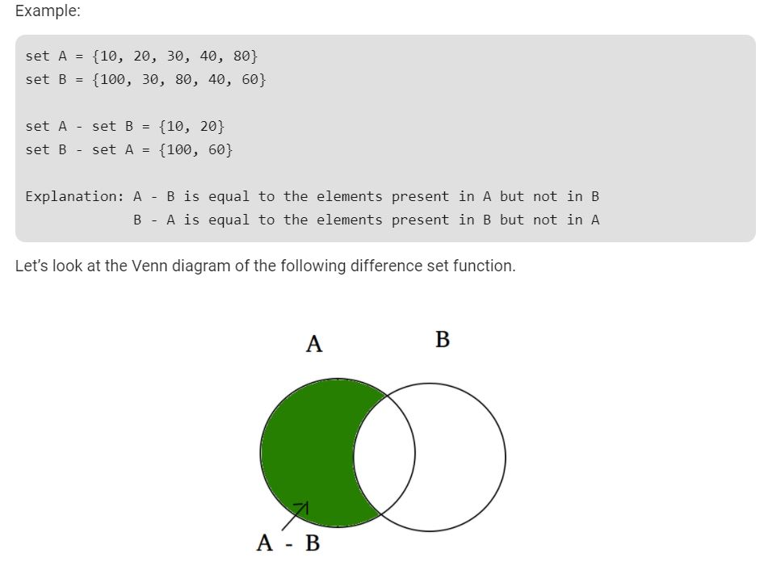

# *Copies and Views*

*A slicing operation creates a view on the original array, which is just a way of accessing array data. Thus the original array is not copied in the memory. You can use np.may_share_mmeory() to check if two arrays share the same memory block.*

*When modifying the view the original array is modified as well:*

```python
a = np.arange(10)
print(a)
```

```
[0 1 2 3 4 5 6 7 8 9]
```

```python
b = a[::2]
print(b)
```

```
[0 2 4 6 8]
```

```python
np.shares_memory(a, b)
```

```
True
```

```python
b[0] = 10

print(b)
```

```
[10  2  4  6  8]
```

```python
a # evern though we modified b, it updated 'a' because both shares same memory
```

```
array([10,  1,  2,  3,  4,  5,  6,  7,  8,  9])
```

```python
a = np.arange(10)

c = a[::2].copy()  # force a copy

print(c)
```

```
[0 2 4 6 8]
```

```python
np.shares_memory(a, c)
```

```
False
```

```python
c[0] = 12

print(a)     # copy does not affect the original array
```

```
[0 1 2 3 4 5 6 7 8 9]
```

## *Fancy Indexing*

*NumPy arrays can be indexed with slices, but also with boolean or integer arrays (masks). This method is called Fancy indexing. It creates copies not views.*

*Using NumPy mask*

```python
a = np.random.randint(0, 20, 15)    # from 0 to 20 , 15 values

print(a)
```

```
[19  0 10 15 12  8 14  6 17  9  4  6 10  1  6]
```

```python
mask = (a % 2 == 0)

print(mask)
```

```
[False  True  True False  True  True  True  True False False  True  True
  True False  True]
```

```python
extract_from_a = a[mask]

extract_from_a
```

```
array([ 0, 10, 12,  8, 14,  6,  4,  6, 10,  6])
```

## *Indexing with a mask can be very usefull to assign a new value to a sub-array.*

```python
a = np.arange(0, 100, 10)

print(a)
```

```
[ 0 10 20 30 40 50 60 70 80 90]
```

```python
# Indexing can be done with an array of integers, where the same index is repeated several time.

a[[2, 3, 2, 4, 2]]     # multiple times you can call the index
```

```
array([20, 30, 20, 40, 20])
```

```python
# New values can be assigned   to multiple index

a[[9, 7]] = -200

a
```

```
array([   0,   10,   20,   30,   40,   50,   60, -200,   80, -200])
```